# Inteligencia Artificial

### Escuela de Ciencia, Ingenieria y Tecnología

### Universidad del Rosario

**Natalia Laiton Romero - Yofer Quintanilla Gómez**

# Instalaciones

```python
# En linux o mac
#!pip3 install gymnasium[toy-text]
#!pip3 install -r requirements.txt
# En windows
#!py -m pip install -r requirements.txt
#!py -m pip install gymnasium[toy-text]
#!python -m pip install -r requirements.txt
#!python -m pip install gymnasium[toy-text]
```

# Importaciones

**De Python:**

```python
from IPython import display
from time import sleep
import gymnasium as gym
from gymnasium.envs.toy_text.frozen_lake import generate_random_map
from gymnasium.wrappers import TimeLimit
from gymnasium.utils.save_video import save_video
import seaborn as sns
import matplotlib.pyplot as plt
from copy import deepcopy
import numpy as np
import pandas as pd
import time
```

**Del notebook:**

```python
from ambientes import *
from random import random
from plot_utils import PlotGridValues, Plot

%reload_ext autoreload
%autoreload 2
```

# Secciones

### Ambientes

1. ABC.
2. Frozen Lake.
3. Taxi.
4. BlackJack.

Antes de iniciar con los ambientes, definiremos una función para renderizar el estado actual de un agente cuando incislizamos el render mode como rgb_array.

```python
def render(env):
    im = env.render()
    img = plt.imshow(np.array([[0, 0], [0, 0]]))
    img.set_data(im)
    plt.axis('off')
```

## ABC

(Volver a Ejemplos)

[figure not shown]

```python
# Instantiate the environment
env = ABC()
print("Acciones posibles (valores):", env.action_space)
print("Acciones posibles (nombres):", np.vectorize(env.dict_acciones.get)(env.action_space))
print('')
print("Número de acciones posibles:", len(env.action_space))
print('')
a = np.random.choice(env.action_space)
print("Una acción posible seleccionada al azar:", env.dict_acciones[a])
print('')
print("El estado actual es:", env.state, "que corresponde a", env.dict_states[env.state])
```

```
Acciones posibles (valores): [0, 1]
Acciones posibles (nombres): ['LEFT' 'RIGHT']

Número de acciones posibles: 2

Una acción posible seleccionada al azar: RIGHT

El estado actual es: 0 que corresponde a A
```

```python
LEARNING_RATE = 0.9
DISCOUNT = 0.9
EPISODES = 50
SHOW_INT = 1
```

```python
q_table = list()
for i in range(3):
    my_list = list()
    for j in range(2):
        my_list.append(0)
    q_table.append(my_list)


my_pd = pd.DataFrame(q_table)
my_pd = my_pd.rename(
columns = {

0:'Izquierda',
1:'Derecha'


}
)

my_pd
```

|  | Izquierda | Derecha |
| --- | --- | --- |
| 0 | 0 | 0 |
| 1 | 0 | 0 |
| 2 | 0 | 0 |

```python
env = ABC()
recompensas_train = list()
for e in range(EPISODES):
    discrete_state = env.reset()

    env.set_P()

    action = np.random.choice(env.action_space)

    done = False
    my_r = 0
    while not done:

        new_state, r, done = env.step(action)
        #print(action, new_state)
        my_r += r
        next_action = np.random.choice(env.action_space)
        if not done:
            nq = r + DISCOUNT*q_table[new_state][next_action] - q_table[discrete_state][action]
            #print(nq)
            q_table[discrete_state][action] += (nq*LEARNING_RATE)
        else:
            nq = r - q_table[discrete_state][action]
            q_table[discrete_state][action] += (nq*LEARNING_RATE)

        discrete_state = new_state
        action = next_action
    recompensas_train.append(my_r)


print('Recompensa promedio: ', sum(recompensas_train)/len(recompensas_train))
```

```
Recompensa promedio:  4.3
```

```python
my_new_pd = pd.DataFrame(q_table)
my_new_pd = my_new_pd.rename(
columns = {

0:'Izquierda',
1:'Derecha'


}
)

my_new_pd
```

|  | Izquierda | Derecha |
| --- | --- | --- |
| 0 | -1.823043 | 7.044552 |
| 1 | 3.987057 | 10.000000 |
| 2 | 0.000000 | 0.000000 |

```python
TEST_LEN = 20
```

```python
env = ABC()
recompensa = list()

for _ in range(TEST_LEN):

    obs = env.reset()

    discrete_state = obs

    done = False

    my_r = 0

    while not done:
        action = np.argmax(q_table[discrete_state])
        #print(action)
        new_state, r, done = env.step(action)
            #print(action, new_state)


        my_r += r

        discrete_state = new_state



    recompensa.append(my_r)
print('Recompensa promedio: ',sum(recompensa)/len(recompensa))
```

```
Recompensa promedio:  8.9
```

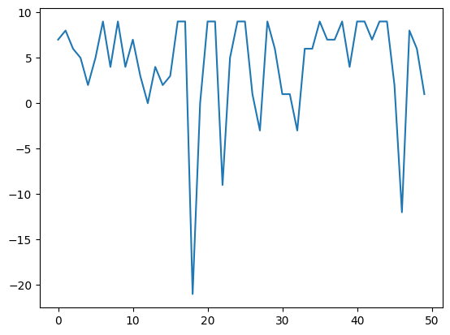

```python
plt.plot(recompensas_train)
plt.show()
```

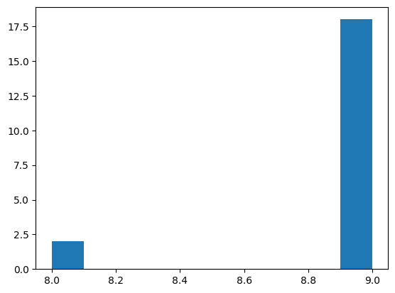

```python
plt.hist(recompensa)
plt.show()
```

```python
pi = list()
estados = ['LEFT', 'RIGHT']

for i in range(len(q_table)):
    s = q_table[i]
    pi_a = np.argmax(s)
    #v = s[pi_a]

    pi.append(pi_a)

print(pi)
```

```
[1, 1, 0]
```

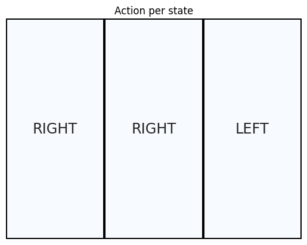

```python
policy = pi
pp = PlotGridValues(shape=(1,3), dict_acciones=env.dict_acciones)
pp.plot_policy(policy)
```

## Frozen lake

(Volver al Inicio)

[Código Fuente](https://github.com/Farama-Foundation/Gymnasium/blob/main/gymnasium/envs/toy_text/frozen_lake.py)

```
Observacion inicial:  (0, {'prob': 1})
Número de acciones posibles: 4
Acciones posibles: Discrete(4)
Una acción posible seleccionada al azar: 3
```

[figure not shown]

```python
#Creación del ambiente
env = gym.make('FrozenLake-v1',
               desc = ["SFFF", "FFHF", "FHFF", "FFFG"],
               map_name = '4x4',
               is_slippery = True,
               render_mode='rgb_array')
#Inicialización del ambiente
obs = env.reset()
#Caracterización del ambiente
print("Observacion inicial: ", obs)
print("Número de acciones posibles:", env.action_space.n)
print("Acciones posibles:", env.action_space)
print("Una acción posible seleccionada al azar:", env.action_space.sample())
render(env)
```

```python
LEARNING_RATE = 0.9
DISCOUNT = 0.9
EPISODES = 20001
SHOW_INT = 10000
```

```python
q_table = list()
for i in range(16):
    my_list = list()
    for j in range(4):
        my_list.append(random()/5)
    q_table.append(my_list)
my_pd = pd.DataFrame(q_table)
my_pd = my_pd.rename(
columns = {

0:'Izquierda',
1:'Abajo',
2:'Derecha',
3:'Arriba'

}
)

my_pd
```

|  | Izquierda | Abajo | Derecha | Arriba |
| --- | --- | --- | --- | --- |
| 0 | 0.183063 | 0.176865 | 0.092821 | 0.155011 |
| 1 | 0.087140 | 0.137694 | 0.167193 | 0.080746 |
| 2 | 0.097238 | 0.173961 | 0.084071 | 0.096371 |
| 3 | 0.161043 | 0.106685 | 0.149422 | 0.118111 |
| 4 | 0.076414 | 0.099371 | 0.160630 | 0.175243 |
| 5 | 0.005433 | 0.087741 | 0.129139 | 0.156487 |
| 6 | 0.041473 | 0.109674 | 0.196377 | 0.069255 |
| 7 | 0.121648 | 0.054632 | 0.085220 | 0.098091 |
| 8 | 0.008324 | 0.168928 | 0.175288 | 0.091664 |
| 9 | 0.131791 | 0.166298 | 0.028454 | 0.028808 |
| 10 | 0.198964 | 0.191566 | 0.028895 | 0.182610 |
| 11 | 0.100983 | 0.019805 | 0.007674 | 0.054209 |
| 12 | 0.016834 | 0.123669 | 0.098927 | 0.057594 |
| 13 | 0.057630 | 0.148704 | 0.005227 | 0.120969 |
| 14 | 0.179484 | 0.131364 | 0.088871 | 0.053352 |
| 15 | 0.075493 | 0.187906 | 0.092513 | 0.126923 |

```python
recompensas_train = list()
for e in range(EPISODES):
    obs = env.reset()
    if e%SHOW_INT == 0:
        rend = True
    else:
        rend = False
    #print(rend)
    #Mi estado inicial
    discrete_state = obs[0]

    done = False

    my_r = 0
    while not done:
        #if rend:
            #pass
            #print(e)
            #render(env)
            #env.render()
            #print(discrete_state, new_state)

        action = np.argmax(q_table[discrete_state])
        new_state, r, done, _, _ = env.step(action)

        my_r += r


        if not done:
            max_future_qpi = np.max(q_table[new_state])
            curren_qpi = q_table[discrete_state][action]
            nq = curren_qpi + LEARNING_RATE*(r + DISCOUNT*max_future_qpi - curren_qpi)
            q_table[discrete_state][action] = nq
        else:
            q_table[discrete_state][action] = r
        discrete_state = new_state
    recompensas_train.append(my_r)
print('Recompensa promedio: ', sum(recompensas_train)/len(recompensas_train))
```

```
Recompensa promedio:  0.9970001499925004
```

[figure not shown]

```python
render(env)
env.close()
```

```python
my_pd_new = pd.DataFrame(q_table)
my_pd_new = my_pd_new.rename(
columns = {

0: 'Izquierda',
1:'Abajo',
2: 'Derecha',
3:'Arriba'

}
)

my_pd_new
```

|  | Izquierda | Abajo | Derecha | Arriba |
| --- | --- | --- | --- | --- |
| 0 | 0.002270 | 0.202228 | 0.002139 | 0.002137 |
| 1 | 0.001885 | 0.001758 | 0.000244 | 0.464017 |
| 2 | 0.000000 | 0.000000 | 0.000000 | 0.671733 |
| 3 | 0.007699 | 0.007258 | 0.803107 | 0.007961 |
| 4 | 0.172049 | 0.001609 | 0.000840 | 0.002248 |
| 5 | 0.001861 | 0.000000 | 0.000000 | 0.000000 |
| 6 | 0.041473 | 0.109674 | 0.196377 | 0.069255 |
| 7 | 0.000000 | 0.000000 | 0.899722 | 0.000000 |
| 8 | 0.224411 | 0.000000 | 0.000000 | 0.000000 |
| 9 | 0.131791 | 0.166298 | 0.028454 | 0.028808 |
| 10 | 0.000000 | 0.000000 | 0.000000 | 0.000000 |
| 11 | 0.007389 | 0.001000 | 1.000000 | 0.005421 |
| 12 | 0.013549 | 0.321271 | 0.013676 | 0.013023 |
| 13 | 0.000000 | 0.836659 | 0.005227 | 0.000000 |
| 14 | 0.027823 | 1.000000 | 0.010000 | 0.005335 |
| 15 | 0.075493 | 0.187906 | 0.092513 | 0.126923 |

```python
env = gym.make('FrozenLake-v1',
               desc = ["SFFF", "FFHF", "FHFF", "FFFG"],
               map_name = '4x4',
               is_slippery = True,
               render_mode='human')
obs = env.reset()

discrete_state = obs[0]

done = False
while not done:
    action = np.argmax(q_table[discrete_state])
    new_state, r, done, _, _ = env.step(action)
    discrete_state = new_state

env.close()
```

```python
TEST_LEN = 350
```

```python
env = gym.make('FrozenLake-v1',
               desc = ["SFFF", "FFHF", "FHFF", "FFFG"],
               map_name = '4x4',
               is_slippery = True,
               render_mode='rgb_array')
recompensa = list()
for _ in range(TEST_LEN):
    obs = env.reset()

    discrete_state = obs[0]

    done = False

    my_r = 0
    while not done:
        action = np.argmax(q_table[discrete_state])
        new_state, r, done, _, _ = env.step(action)

        my_r += r

        discrete_state = new_state
    recompensa.append(my_r)
print('Recompensa promedio: ',sum(recompensa)/len(recompensa))
env.close()
```

```
Recompensa promedio:  1.0
```

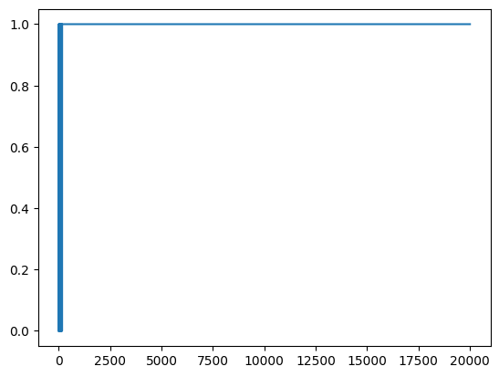

```python
plt.plot(recompensas_train)
plt.show()
```

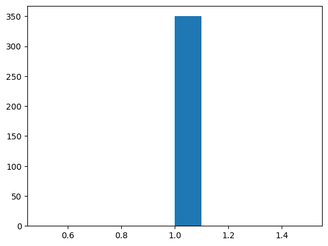

```python
plt.hist(recompensa)
plt.show()
```

```python
pi = [[],[],[],[]]

for i in range(len(q_table)):

    s = q_table[i]

    pi_a = np.argmax(s)
    #v = s[pi_a]

    pi[i%4].append(pi_a)

print(pi)
```

```
[[1, 0, 0, 1], [3, 0, 1, 1], [3, 2, 0, 1], [2, 2, 2, 1]]
```

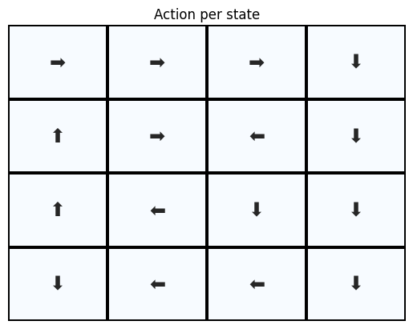

```python
dict_acciones = { 0:"⬅", 1:"⬇", 2:"➡",3:"⬆"}
policy = pi
pp = PlotGridValues(shape=(4,4), dict_acciones=dict_acciones)
pp.plot_policy(policy)
```

Antes de iniciar el próximo ambiente declararermos una función para generar un video de un episodio especifico.

```python
def genVideo(env= None, file = 'TaxiEnv'):
    frame_list = list()

    obs = env.reset()

    discrete_state = obs[0]
    des, p, ct, ft = decoRes(discrete_state)

    done = False

    while not done:

        im = env.render()

        if isinstance(im, np.ndarray):
            frame_list.append(im)

        action = np.argmax(q_table[ft][ct][p][des])

        new_state, r, done, _, _ = env.step(action)
        ndes, nwp, nct, nft = decoRes(new_state)



        discrete_state = new_state
        des, p, ct, ft = ndes, nwp, nct, nft



    save_video(frames=frame_list,video_folder=file, fps=1/0.3)
```

## Taxi

(Volver a Ejemplos)

```
Observacion inicial:  (126, {'prob': 1.0, 'action_mask': array([1, 1, 0, 1, 0, 0], dtype=int8)})
Número de acciones posibles: 6
Acciones posibles: Discrete(6)
Una acción posible seleccionada al azar: 4
```

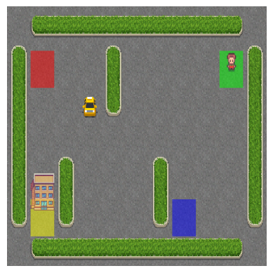

```python
env = gym.make('Taxi-v3', render_mode="rgb_array")
#Inicialización del ambiente
obs = env.reset()
#Caracterización del ambiente
print("Observacion inicial: ", obs)
print("Número de acciones posibles:", env.action_space.n)
print("Acciones posibles:", env.action_space)
print("Una acción posible seleccionada al azar:", env.action_space.sample())
render(env)
```

```python
def decoRes(n):
    #Destino
    des = n%4
    n = (n - des)/4

    #Recogida del pasajero
    p = n%5
    n = (n - p)/5

    #Columna taxi
    ct = n%5
    n = (n - ct)/5

    #Columna taxi
    ft = n

    return int(des), int(p), int(ct), int(ft)
```

```python
des, p, ct, ft = decoRes(obs[0])
print(des, p, ct, ft)
```

```
2 1 1 1
```

```python
q_table = list()
for _ in range(5):
    my_row_list = list()
    for _ in range(5):
        my_col_list = list()
        for _ in range(5):
            my_pas_list = list()
            for _ in range(4):
                my_des_list = list()
                for _ in range(6):
                    my_des_list.append(0)
                my_pas_list.append(my_des_list)
            my_col_list.append(my_pas_list)
        my_row_list.append(my_col_list)
    q_table.append(my_row_list)
```

```python
#Generaremos un video del comportamiento previo al entrenamiento
#genVideo(env)
```

Al intentar guardar el video se genera un error causado por la gran cantidad de frames que tienen que ser almacenados antes de que el entorno de manera aleatoria llegue a su fin, pero esto no es solamente causado por esto, sino que además el proceso de renderizar es bastante demorado computacionalmente. Por lo tanto, se decide proceder sin este mismo

```python
LEARNING_RATE = 0.9
DISCOUNT = 0.9
EPISODES = 300
SHOW_INT = 100
```

```python
recompensas_train = list()

for e in range(EPISODES):
    obs = env.reset()

    discrete_state = obs[0]
    des, p, ct, ft = decoRes(discrete_state)

    done = False

    my_r = 0
    while not done:

        action = np.argmax(q_table[ft][ct][p][des])

        new_state, r, done, _, _ = env.step(action)
        ndes, nwp, nct, nft = decoRes(new_state)

        my_r += r

        if not done:
            max_future_qpi = np.max(q_table[nft][nct][nwp][ndes])
            curren_qpi = q_table[ft][ct][p][des][action]
            nq = curren_qpi + LEARNING_RATE*(r + DISCOUNT*max_future_qpi - curren_qpi)
            q_table[ft][ct][p][des][action] = nq
        else:
            q_table[ft][ct][p][des][action] = r

        discrete_state = new_state
        des, p, ct, ft = decoRes(discrete_state)
    recompensas_train.append(my_r)

print('Recompensa promedio: ', sum(recompensas_train)/len(recompensas_train))
```

```
Recompensa promedio:  -70.62
```

Por la alta cantidad de estados, puede que aunque el taxi se comporte generalmente bien en el entrenamiento, pueden quedar muchos estados sin optimizar, por lo cual pueden generarse malos comportamientos al pasar a la etapa de testeo. Por lo tanto, se realizará un entrenamiento más arduo.

```python
EPISODES = 30000
```

```python
for e in range(EPISODES):
    obs = env.reset()

    discrete_state = obs[0]
    des, p, ct, ft = decoRes(discrete_state)

    done = False


    while not done:

        action = np.argmax(q_table[ft][ct][p][des])

        new_state, r, done, _, _ = env.step(action)
        ndes, nwp, nct, nft = decoRes(new_state)


        if not done:
            max_future_qpi = np.max(q_table[nft][nct][nwp][ndes])
            curren_qpi = q_table[ft][ct][p][des][action]
            nq = curren_qpi + LEARNING_RATE*(r + DISCOUNT*max_future_qpi - curren_qpi)
            q_table[ft][ct][p][des][action] = nq
        else:
            q_table[ft][ct][p][des][action] = r

        discrete_state = new_state
        des, p, ct, ft = decoRes(discrete_state)
```

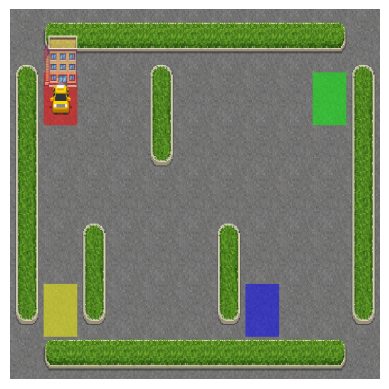

```python
render(env)
#env.close()
```

```python
genVideo(env)
```

```
Moviepy - Building video C:\Users\yofer\OneDrive\Escritorio\IA\Procesos de decisión markovianos-20231121\TaxiEnv/rl-video-episode-0.mp4.
Moviepy - Writing video C:\Users\yofer\OneDrive\Escritorio\IA\Procesos de decisión markovianos-20231121\TaxiEnv/rl-video-episode-0.mp4
```

```
Moviepy - Done !
Moviepy - video ready C:\Users\yofer\OneDrive\Escritorio\IA\Procesos de decisión markovianos-20231121\TaxiEnv/rl-video-episode-0.mp4
```

```python
env = gym.make('Taxi-v3', render_mode="human")
obs = env.reset()

discrete_state = obs[0]
des, p, ct, ft = decoRes(discrete_state)

done = False

while not done:

    action = np.argmax(q_table[ft][ct][p][des])

    new_state, r, done, _, _ = env.step(action)
    ndes, nwp, nct, nft = decoRes(new_state)

    if not done:
        max_future_qpi = np.max(q_table[nft][nct][nwp][ndes])
        curren_qpi = q_table[ft][ct][p][des][action]
        nq = curren_qpi + LEARNING_RATE*(r + DISCOUNT*max_future_qpi - curren_qpi)


    discrete_state = new_state
    des, p, ct, ft = ndes, nwp, nct, nft

env.close()
```

```python
TEST_LEN = 10
```

```python
env = gym.make('Taxi-v3')
recompensas = list()
for _ in range(TEST_LEN):

    obs = env.reset()

    discrete_state = obs[0]
    des, p, ct, ft = decoRes(discrete_state)

    done = False
    my_r = 0

    while not done:

        action = np.argmax(q_table[ft][ct][p][des])

        new_state, r, done, _, _ = env.step(action)
        #print(done)
        ndes, nwp, nct, nft = decoRes(new_state)

        my_r += r

        discrete_state = new_state
        des, p, ct, ft = ndes, nwp, nct, nft

    recompensas.append(my_r)
print('Recompensa promedio: ',sum(recompensas)/len(recompensas))
env.close()
```

```
Recompensa promedio:  7.2
```

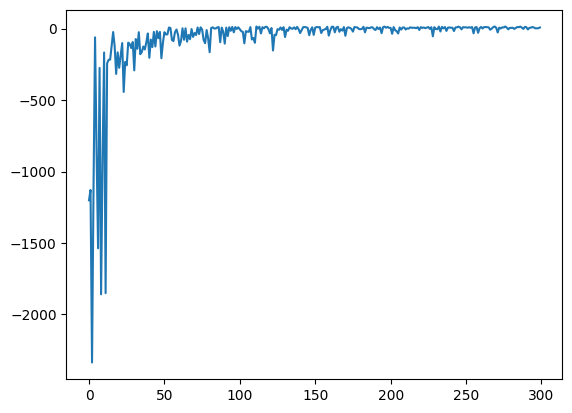

```python
plt.plot(recompensas_train)
plt.show()
```

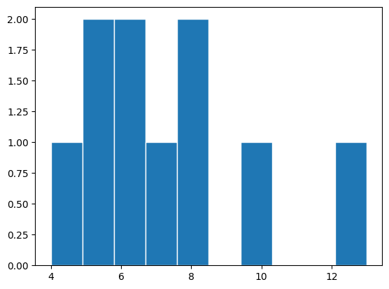

```python
plt.hist(recompensas, edgecolor='white')
plt.show()
```

## Blackjack

(Volver a Ejemplos)

```
Observacion inicial:  ((12, 10, 0), {})
Número de acciones posibles: 2
Acciones posibles: Discrete(2)
Una acción posible seleccionada al azar: 0
```

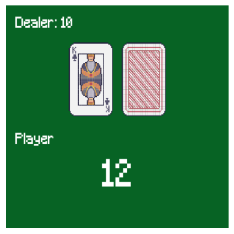

```python
env = gym.make('Blackjack-v1', natural=False, sab=False, render_mode="rgb_array")
#Inicialización del ambiente
obs = env.reset()
#Caracterización del ambiente
print("Observacion inicial: ", obs)
print("Número de acciones posibles:", env.action_space.n)
print("Acciones posibles:", env.action_space)
print("Una acción posible seleccionada al azar:", env.action_space.sample())
render(env)
```

```python
LEARNING_RATE = 0.1
DISCOUNT = 0.3
EPISODES = 1000
SHOW_INT = 50
```

```python
q_table = list()
for _ in range(32):
    player_list = list()
    for _ in range(11):
        dealer_list = list()
        for _ in range(2):
            ace_list = list()
            for _ in range(2):
                ace_list.append(0)
            dealer_list.append(ace_list)
        player_list.append(dealer_list)
    q_table.append(player_list)
```

```python
recompensas_train = list()
for e in range(EPISODES):
    obs = env.reset()

    discrete_state = obs[0]
    p,d,a = discrete_state

    done = False

    my_r = 0

    while not done:

        action = np.argmax(q_table[p][d][a])

        new_state, r, done, _, _ = env.step(action)
        nwp,nd,na = new_state

        my_r += r

        if not done:
            max_future_qpi = np.max(q_table[nwp][nd][na])
            curren_qpi = q_table[p][d][a][action]
            nq = curren_qpi + LEARNING_RATE*(r + DISCOUNT*max_future_qpi - curren_qpi)
            q_table[p][d][a][action] = nq
        else:
            q_table[p][d][a][action] = r

        discrete_state = new_state
        p,d,a = discrete_state
    recompensas_train.append(my_r)

print('Recompensa promedio: ', sum(recompensas_train)/len(recompensas_train))
```

```
Recompensa promedio:  -0.147
```

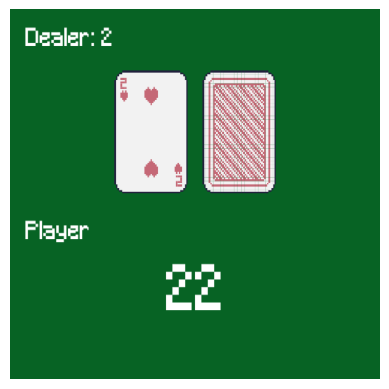

```python
render(env)
env.close()
```

```python
env = gym.make('Blackjack-v1', natural=False, sab=False, render_mode="human")
obs = env.reset()

discrete_state = obs[0]
p,d,a = discrete_state

done = False
r = 0
while not done:

    action = np.argmax(q_table[p][d][a])

    new_state, r, done, _, _ = env.step(action)
    nwp,nd,na = new_state

    discrete_state = new_state
    p,d,a = discrete_state
print(r)
time.sleep(1)
env.close()
```

```
1.0
```

```python
TEST_LEN = 500
```

```python
env = gym.make('Blackjack-v1', natural=False, sab=False, render_mode="rgb_array")
recompensas = list()
for _ in range(TEST_LEN):
    obs = env.reset()

    discrete_state = obs[0]
    p,d,a = discrete_state

    done = False
    my_r = 0

    while not done:

        action = np.argmax(q_table[p][d][a])

        new_state, r, done, _, _ = env.step(action)
        nwp,nd,na = new_state

        my_r += r

        discrete_state = new_state
        p,d,a = discrete_state

    recompensas.append(my_r)
print(sum(recompensas)/len(recompensas))
env.close()
```

```
-0.058
```

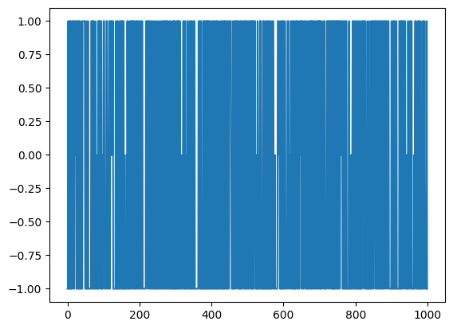

```python
plt.plot(recompensas_train)
plt.show()
```

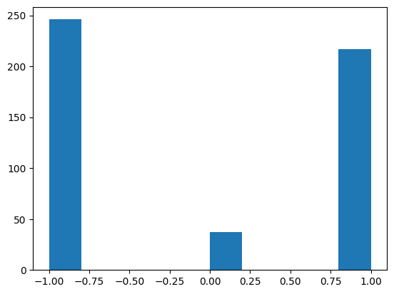

```python
plt.hist(recompensas)
plt.show()
```